# Week 5 Application Exercise

Prof. Amanda D. Perez, PhD

# Simple Regression

```r
library(tidyverse)
library(skimr)
library(scales)
library(forcats)
library(yarrr)
```

We will be using data from 1000 Pirates. Let’s take a glimpse of the data:

```r
# From the yarrr package:
glimpse(pirates)
```

```
## Rows: 1,000
## Columns: 17
## $ id              <int> 1, 2, 3, 4, 5, 6, 7, 8, 9, 10, 11, 12, 13, 14, 15, 16,…
## $ sex             <chr> "male", "male", "male", "female", "female", "male", "f…
## $ age             <dbl> 28, 31, 26, 31, 41, 26, 31, 31, 28, 30, 25, 20, 24, 26…
## $ height          <dbl> 173.11, 209.25, 169.95, 144.29, 157.85, 190.20, 158.05…
## $ weight          <dbl> 70.5, 105.6, 77.1, 58.5, 58.4, 85.4, 59.6, 74.5, 68.7,…
## $ headband        <chr> "yes", "yes", "yes", "no", "yes", "yes", "yes", "yes",…
## $ college         <chr> "JSSFP", "JSSFP", "CCCC", "JSSFP", "JSSFP", "CCCC", "J…
## $ tattoos         <dbl> 9, 9, 10, 2, 9, 7, 9, 5, 12, 12, 10, 14, 8, 9, 14, 8, …
## $ tchests         <dbl> 0, 11, 10, 0, 6, 19, 1, 13, 37, 69, 1, 5, 6, 12, 70, 3…
## $ parrots         <dbl> 0, 0, 1, 2, 4, 0, 7, 7, 2, 4, 3, 3, 0, 3, 0, 1, 0, 3, …
## $ favorite.pirate <chr> "Jack Sparrow", "Jack Sparrow", "Jack Sparrow", "Jack …
## $ sword.type      <chr> "cutlass", "cutlass", "cutlass", "scimitar", "cutlass"…
## $ eyepatch        <dbl> 1, 0, 1, 1, 1, 1, 0, 1, 0, 1, 1, 0, 0, 1, 1, 1, 0, 0, …
## $ sword.time      <dbl> 0.58, 1.11, 1.44, 36.11, 0.11, 0.59, 3.01, 0.06, 0.74,…
## $ beard.length    <dbl> 16, 21, 19, 2, 0, 17, 1, 1, 1, 25, 1, 27, 0, 19, 0, 1,…
## $ fav.pixar       <chr> "Monsters, Inc.", "WALL-E", "Inside Out", "Inside Out"…
## $ grogg           <dbl> 11, 9, 7, 9, 14, 7, 9, 12, 16, 9, 7, 8, 12, 7, 9, 10, …
```

## Exercise 1

I am curious is the amount of grogg (i.e. a pirate drink) a pirate can drink is predicted by how tall they are.

### Visualizing Grogg x Height

Below I have created a basic scatterplot visualization. Your task is to improve the graph by: Cleaning up all of the labels, adding a title, adding a “lm” line, and add a theme. See https://ggplot2-book.org/polishing.html for a list of included themes. Finally, interpret what you see.

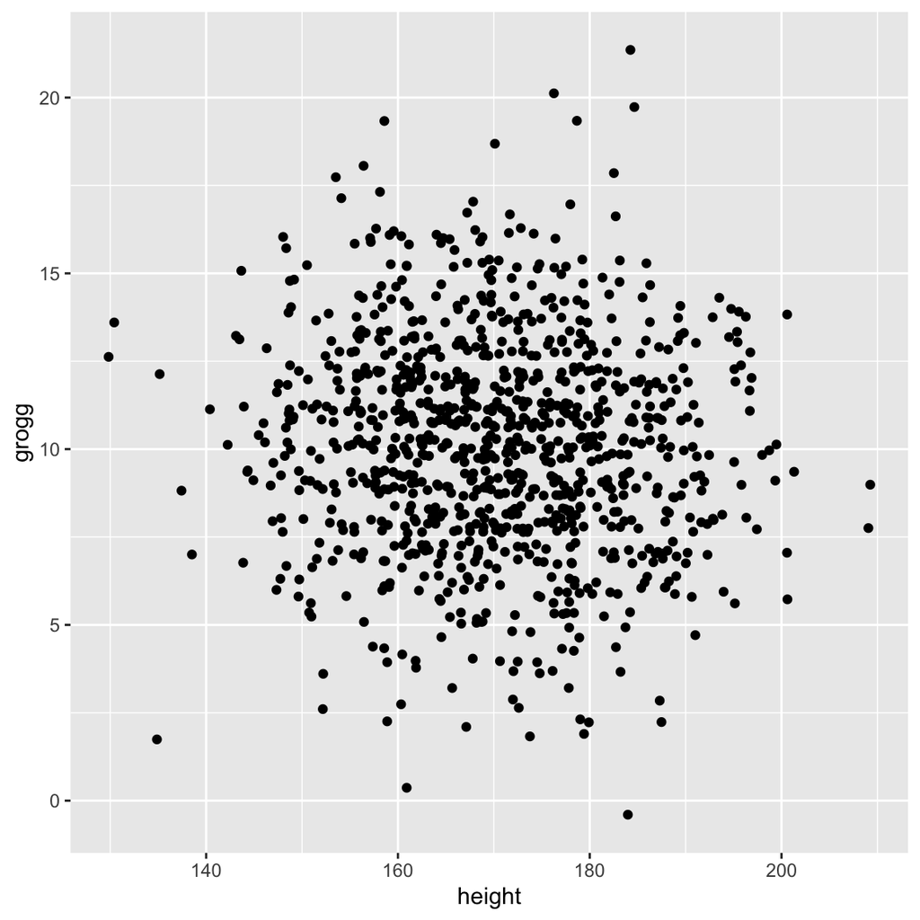

```r
ggplot(pirates, aes(x = height, y = grogg)) +
  geom_jitter()
```

### Simple Regression Grogg x Height

Below I have created the model object `mod.1` where I ran a simple regression predicting grogg drinking from pirate height. Your task is to interpret the model output. Specifically, interpret the: `Intercept`, `height` row, and relevant `p values`.

```r
mod.1 <- lm(grogg ~ height, pirates)
summary(mod.1)
```

```
##
## Call:
## lm(formula = grogg ~ height, data = pirates)
##
## Residuals:
##      Min       1Q   Median       3Q      Max
## -10.2998  -2.0760  -0.0262   1.9275  11.0878
##
## Coefficients:
##              Estimate Std. Error t value Pr(>|t|)
## (Intercept) 12.972757   1.334224   9.723   <2e-16 ***
## height      -0.016612   0.007817  -2.125   0.0338 *
## ---
## Signif. codes:  0 '***' 0.001 '**' 0.01 '*' 0.05 '.' 0.1 ' ' 1
##
## Residual standard error: 3.06 on 998 degrees of freedom
## Multiple R-squared:  0.004504,   Adjusted R-squared:  0.003507
## F-statistic: 4.516 on 1 and 998 DF,  p-value: 0.03383
```

## Exercise 2

I am curious is the amount of tattoos a pirate has is predicted by whether or not they wear a headband.

Below I have created a basic barplot visualization. Your task is to improve the graph by: Cleaning up all of the labels, adding a title, making each bar a different color, and add a theme. See https://ggplot2-book.org/polishing.html for a list of included themes. Finally, interpret what you see.

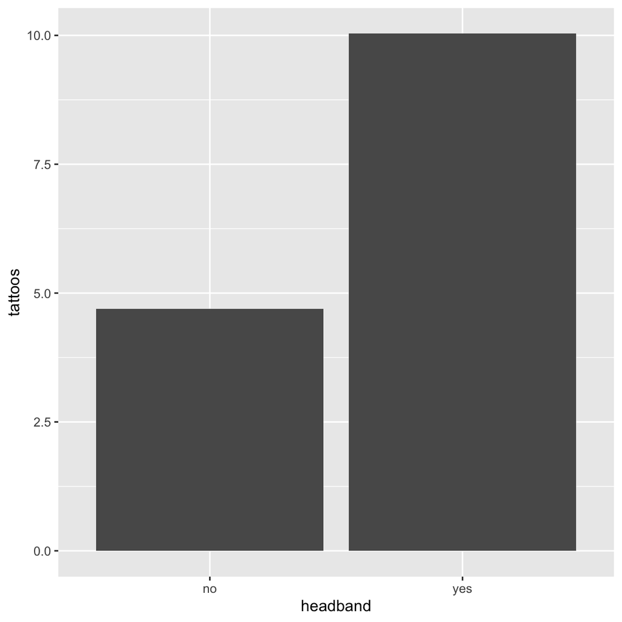

```r
ggplot(pirates, aes(x = headband, y = tattoos)) +
  stat_summary(fun = "mean", geom = "bar")
```

### Simple Regression Tattoos x Headband

Below I have created the model object `mod.2` where I ran a simple regression predicting amount of tattoos from whether or not a pirate wears a headband. Your task is to interpret the model output. Specifically, interpret the: `Intercept`, `headbandyes` row, and relevant `p values`.

```r
levels(as.factor(pirates$headband))
```

```
## [1] "no"  "yes"
```

```r
mod.2 <- lm(tattoos ~ headband, pirates)
summary(mod.2)
```

```
##
## Call:
## lm(formula = tattoos ~ headband, data = pirates)
##
## Residuals:
##      Min       1Q   Median       3Q      Max
## -10.0316  -2.0316  -0.0316   1.9684   8.9684
##
## Coefficients:
##             Estimate Std. Error t value Pr(>|t|)
## (Intercept)   4.6991     0.2742   17.14   <2e-16 ***
## headbandyes   5.3325     0.2912   18.31   <2e-16 ***
## ---
## Signif. codes:  0 '***' 0.001 '**' 0.01 '*' 0.05 '.' 0.1 ' ' 1
##
## Residual standard error: 2.915 on 998 degrees of freedom
## Multiple R-squared:  0.2515, Adjusted R-squared:  0.2508
## F-statistic: 335.4 on 1 and 998 DF,  p-value: < 2.2e-16
```

## Exercise 3: Simple Regression - Your Choice!

Now it is your turn to run a simple regression of your choice with the `pirate` data. Select any numeric variable to be your outcome (DV) and any other type of variable of your choice to be a predictor (IV).

### Create a Visualization

First, create an appropriate visualization of your two variables. Make sure to clean up your plot and interpret what you see.

```r
#ggplot code here
```

Next, fill in the code below to run your simple regression. Interpret the `intercept`, `slope`, and relevant `p values`. Make sure to change `eval` to `TRUE` once you are ready to knit.

```r
mod.3 <- lm(DV.HERE ~ IV.HERE, pirates)
summary(mod.3)
```

# Multiple Regression

We will be using data from the 50 states. You can type `?state.x77` in the console to learn more. Let’s take a glimpse of the data:

```r
states <- as.data.frame(state.x77)
glimpse(states)
```

```
## Rows: 50
## Columns: 8
## $ Population <dbl> 3615, 365, 2212, 2110, 21198, 2541, 3100, 579, 8277, 4931, …
## $ Income     <dbl> 3624, 6315, 4530, 3378, 5114, 4884, 5348, 4809, 4815, 4091,…
## $ Illiteracy <dbl> 2.1, 1.5, 1.8, 1.9, 1.1, 0.7, 1.1, 0.9, 1.3, 2.0, 1.9, 0.6,…
## $ `Life Exp` <dbl> 69.05, 69.31, 70.55, 70.66, 71.71, 72.06, 72.48, 70.06, 70.…
## $ Murder     <dbl> 15.1, 11.3, 7.8, 10.1, 10.3, 6.8, 3.1, 6.2, 10.7, 13.9, 6.2…
## $ `HS Grad`  <dbl> 41.3, 66.7, 58.1, 39.9, 62.6, 63.9, 56.0, 54.6, 52.6, 40.6,…
## $ Frost      <dbl> 20, 152, 15, 65, 20, 166, 139, 103, 11, 60, 0, 126, 127, 12…
## $ Area       <dbl> 50708, 566432, 113417, 51945, 156361, 103766, 4862, 1982, 5…
```

## Exercise 4: Multiple Regression with Main Effects

Below I have created the model object `mod.main` where I ran a multiple regression predicting life expectancy from Income and Frost (mean number of days with minimum temperature below freezing). Your task is to interpret the model output. Specifically, interpret the: `Intercept`, `Income` row, `Frost` row, and relevant `p values`.

```r
mod.main <- lm(`Life Exp` ~ Income + Frost, states)
summary(mod.main)
```

```
##
## Call:
## lm(formula = `Life Exp` ~ Income + Frost, data = states)
##
## Residuals:
##      Min       1Q   Median       3Q      Max
## -3.02375 -0.86571 -0.09283  0.90638  2.90656
##
## Coefficients:
##              Estimate Std. Error t value Pr(>|t|)
## (Intercept) 6.748e+01  1.316e+00  51.287   <2e-16 ***
## Income      6.469e-04  3.013e-04   2.147    0.037 *
## Frost       5.037e-03  3.561e-03   1.414    0.164
## ---
## Signif. codes:  0 '***' 0.001 '**' 0.01 '*' 0.05 '.' 0.1 ' ' 1
##
## Residual standard error: 1.262 on 47 degrees of freedom
## Multiple R-squared:  0.1519, Adjusted R-squared:  0.1158
## F-statistic: 4.208 on 2 and 47 DF,  p-value: 0.02084
```

## Exercise 5: Multiple Regression with an Interaction Effect

Below I have created the model object `mod.int` where I ran a multiple regression predicting life expectancy from Income and Frost (mean number of days with minimum temperature below freezing). In addition, I am testing the interaction of Income and Frost on Life Expectancy, Your task is to interpret the model output. Specifically, interpret the: `Intercept`, `Income` row, `Frost` row, and relevant `p values`. The `Income:Frost` row is the row that tests the interaction. For this row, you only have to interpret the `p value` and not the estimate. You will interpret the interaction in the next exercise (#6).

```r
mod.int <- lm(`Life Exp` ~ Income * Frost, states)
summary(mod.int)
```

```
##
## Call:
## lm(formula = `Life Exp` ~ Income * Frost, data = states)
##
## Residuals:
##     Min      1Q  Median      3Q     Max
## -1.7176 -0.8212 -0.2645  0.9328  1.9908
##
## Coefficients:
##                Estimate Std. Error t value Pr(>|t|)
## (Intercept)   5.826e+01  2.491e+00  23.394  < 2e-16 ***
## Income        2.731e-03  5.646e-04   4.837 1.51e-05 ***
## Frost         9.850e-02  2.269e-02   4.341 7.70e-05 ***
## Income:Frost -2.081e-05  5.005e-06  -4.157 0.000139 ***
## ---
## Signif. codes:  0 '***' 0.001 '**' 0.01 '*' 0.05 '.' 0.1 ' ' 1
##
## Residual standard error: 1.088 on 46 degrees of freedom
## Multiple R-squared:  0.3835, Adjusted R-squared:  0.3433
## F-statistic: 9.539 on 3 and 46 DF,  p-value: 5.18e-05
```

## Exercise 6: Visualizing the Interaction

The visualization below plots the interaction of Income*Frost on Life Expectancy. You can interpret `+1 SD` as “High Frost” and `-1 SD` as “Low Frost”

Below the graph write your interpretation of how Income and Frost interact to predict Life Expectancy.

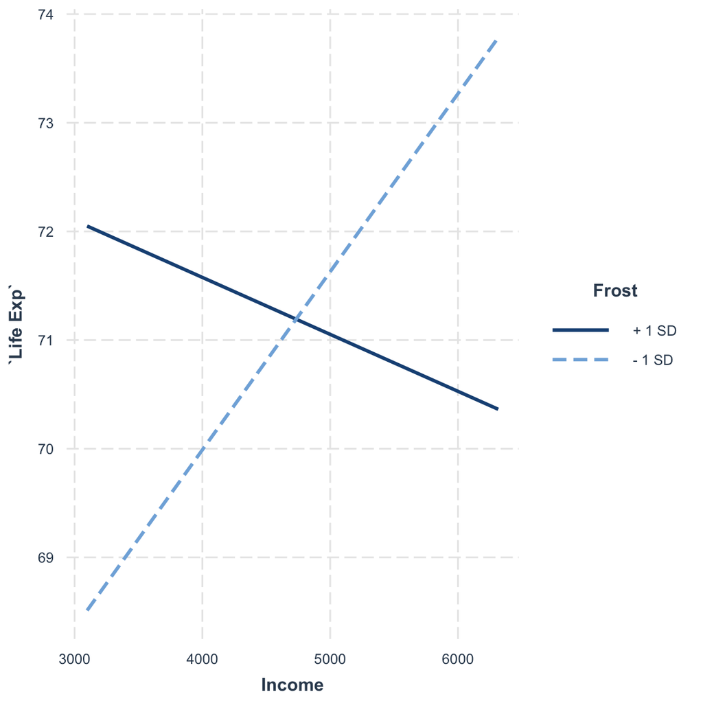

```r
library(interactions)
interact_plot(mod.int, pred = Income, modx = Frost, modx.values = "plus-minus")
```

## Exercise 7: Model Comparison

We have run two models: `mod.main` and `mod.int`

Your task is to decide which model is the most optimal. Which of the below objects would you use to compare the models? Then, do so. Which model is most optimal and why?

```r
objects(summary(mod.main))
```

```
##  [1] "adj.r.squared" "aliased"       "call"          "coefficients"
##  [5] "cov.unscaled"  "df"            "fstatistic"    "r.squared"
##  [9] "residuals"     "sigma"         "terms"
```

```r
objects(summary(mod.int))
```

```
##  [1] "adj.r.squared" "aliased"       "call"          "coefficients"
##  [5] "cov.unscaled"  "df"            "fstatistic"    "r.squared"
##  [9] "residuals"     "sigma"         "terms"
```

```r
summary(mod.int)$fstatistic #example of how to index from the model summary
```

```
##     value     numdf     dendf
##  9.538753  3.000000 46.000000
```

# Logistic Regression

With logistic regression, the change is that our outcome variable (DV) is now binary (0,1). We will walk through an example using simulated data from UCLA’s stats department.

*A researcher is interested in how variables, such as GRE (Graduate Record Exam scores), GPA (grade point average) and prestige of the undergraduate institution, effect admission into graduate school. The response variable, admit/don’t admit, is a binary variable.*

```r
mydata <- read.csv("https://stats.idre.ucla.edu/stat/data/binary.csv")
glimpse(mydata)
```

```
## Rows: 400
## Columns: 4
## $ admit <int> 0, 1, 1, 1, 0, 1, 1, 0, 1, 0, 0, 0, 1, 0, 1, 0, 0, 0, 0, 1, 0, 1…
## $ gre   <int> 380, 660, 800, 640, 520, 760, 560, 400, 540, 700, 800, 440, 760,…
## $ gpa   <dbl> 3.61, 3.67, 4.00, 3.19, 2.93, 3.00, 2.98, 3.08, 3.39, 3.92, 4.00…
## $ rank  <int> 3, 3, 1, 4, 4, 2, 1, 2, 3, 2, 4, 1, 1, 2, 1, 3, 4, 3, 2, 1, 3, 2…
```

Below I create a logistic regression model object called `mod.log`

This predicts admission from gpa.

```r
mod.log <- glm(admit ~ gpa, data = mydata, family = "binomial")
summary(mod.log)
```

```
##
## Call:
## glm(formula = admit ~ gpa, family = "binomial", data = mydata)
##
## Deviance Residuals:
##     Min       1Q   Median       3Q      Max
## -1.1131  -0.8874  -0.7566   1.3305   1.9824
##
## Coefficients:
##             Estimate Std. Error z value Pr(>|z|)
## (Intercept)  -4.3576     1.0353  -4.209 2.57e-05 ***
## gpa           1.0511     0.2989   3.517 0.000437 ***
## ---
## Signif. codes:  0 '***' 0.001 '**' 0.01 '*' 0.05 '.' 0.1 ' ' 1
##
## (Dispersion parameter for binomial family taken to be 1)
##
##     Null deviance: 499.98  on 399  degrees of freedom
## Residual deviance: 486.97  on 398  degrees of freedom
## AIC: 490.97
##
## Number of Fisher Scoring iterations: 4
```

**The logistic regression coefficients give the change in the log odds of the outcome for a one unit increase in the predictor variable.**

For a one unit increase in gpa, the log odds of being admitted to graduate school (versus non-admission) increases by 1.05. This is a significant main effect.

## Exercise 8: Make 4 predictions

Now, your job is to make predictions for 4 different gpa values of your choice and interpret how they impact the probability of admission. I have put in the placeholder values of “1, 2, 3, 4”

Your job is to replace these with 4 different gpa values and to then interpret how they impact admission probability.

```r
test.values <- data.frame(gpa = c(1, 2, 3, 4))
mod.log %>% predict(test.values, type = "response") %>%
  round(2)
```

```
##    1    2    3    4
## 0.04 0.09 0.23 0.46
```

## Exercise 9

### Interpret the logistic regression

Below I create a logistic regression model object called `mod.log2`

This predicts admission from gre. Your job is to interpret the output below (as I did in the previous exercise with gpa).

```r
mod.log2 <- glm(admit ~ gre, data = mydata, family = "binomial")
summary(mod.log2)
```

```
##
## Call:
## glm(formula = admit ~ gre, family = "binomial", data = mydata)
##
## Deviance Residuals:
##     Min       1Q   Median       3Q      Max
## -1.1623  -0.9052  -0.7547   1.3486   1.9879
##
## Coefficients:
##              Estimate Std. Error z value Pr(>|z|)
## (Intercept) -2.901344   0.606038  -4.787 1.69e-06 ***
## gre          0.003582   0.000986   3.633  0.00028 ***
## ---
## Signif. codes:  0 '***' 0.001 '**' 0.01 '*' 0.05 '.' 0.1 ' ' 1
##
## (Dispersion parameter for binomial family taken to be 1)
##
##     Null deviance: 499.98  on 399  degrees of freedom
## Residual deviance: 486.06  on 398  degrees of freedom
## AIC: 490.06
##
## Number of Fisher Scoring iterations: 4
```

### Make 4 predictions

Now, your job is to make predictions for 4 different gre values of your choice and interpret how they impact the probability of admission. I have put in the placeholder values of “1, 2, 3, 4”

Your job is to replace these with 4 different gre values and to then interpret how they impact admission probability.

```r
test.values <- data.frame(gre = c(1, 2, 3, 4))
mod.log2 %>% predict(test.values, type = "response") %>%
  round(2)
```

```
##    1    2    3    4
## 0.05 0.05 0.05 0.05
```

# Transformations

For this section we will be using the built-in R dataset `USJudgeRatings`. This contains lawyers’ ratings of state judges in the US Superior Court. You can type `?USJudgeRatings` into the console to learn more.

```r
judges <- as.data.frame(USJudgeRatings)
glimpse(judges)
```

```
## Rows: 43
## Columns: 12
## $ CONT <dbl> 5.7, 6.8, 7.2, 6.8, 7.3, 6.2, 10.6, 7.0, 7.3, 8.2, 7.0, 6.5, 6.7,…
## $ INTG <dbl> 7.9, 8.9, 8.1, 8.8, 6.4, 8.8, 9.0, 5.9, 8.9, 7.9, 8.0, 8.0, 8.6, …
## $ DMNR <dbl> 7.7, 8.8, 7.8, 8.5, 4.3, 8.7, 8.9, 4.9, 8.9, 6.7, 7.6, 7.6, 8.2, …
## $ DILG <dbl> 7.3, 8.5, 7.8, 8.8, 6.5, 8.5, 8.7, 5.1, 8.7, 8.1, 7.4, 7.2, 6.8, …
## $ CFMG <dbl> 7.1, 7.8, 7.5, 8.3, 6.0, 7.9, 8.5, 5.4, 8.6, 7.9, 7.3, 7.0, 6.9, …
## $ DECI <dbl> 7.4, 8.1, 7.6, 8.5, 6.2, 8.0, 8.5, 5.9, 8.5, 8.0, 7.5, 7.1, 6.6, …
## $ PREP <dbl> 7.1, 8.0, 7.5, 8.7, 5.7, 8.1, 8.5, 4.8, 8.4, 7.9, 7.1, 6.9, 7.1, …
## $ FAMI <dbl> 7.1, 8.0, 7.5, 8.7, 5.7, 8.0, 8.5, 5.1, 8.4, 8.1, 7.2, 7.0, 7.3, …
## $ ORAL <dbl> 7.1, 7.8, 7.3, 8.4, 5.1, 8.0, 8.6, 4.7, 8.4, 7.7, 7.1, 7.0, 7.2, …
## $ WRIT <dbl> 7.0, 7.9, 7.4, 8.5, 5.3, 8.0, 8.4, 4.9, 8.5, 7.8, 7.2, 7.1, 7.2, …
## $ PHYS <dbl> 8.3, 8.5, 7.9, 8.8, 5.5, 8.6, 9.1, 6.8, 8.8, 8.5, 8.4, 6.9, 8.1, …
## $ RTEN <dbl> 7.8, 8.7, 7.8, 8.7, 4.8, 8.6, 9.0, 5.0, 8.8, 7.9, 7.7, 7.2, 7.7, …
```

Below I plot the variable `PHYS`, which is the physical ability of the judges. As you can see, we have a skew.

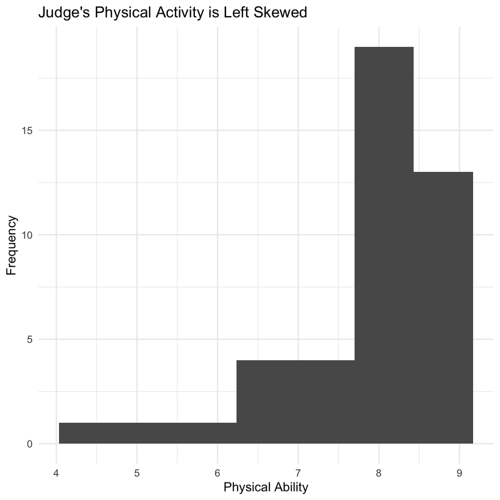

```r
ggplot(judges, aes(PHYS)) +
  geom_histogram(bins = 7) +
  theme_minimal() +
  labs(x = "Physical Ability", y = "Frequency", title = "Judge's Physical Activity is Left Skewed")
```

By applying a `log` transformation I am able to help normalize the variable.

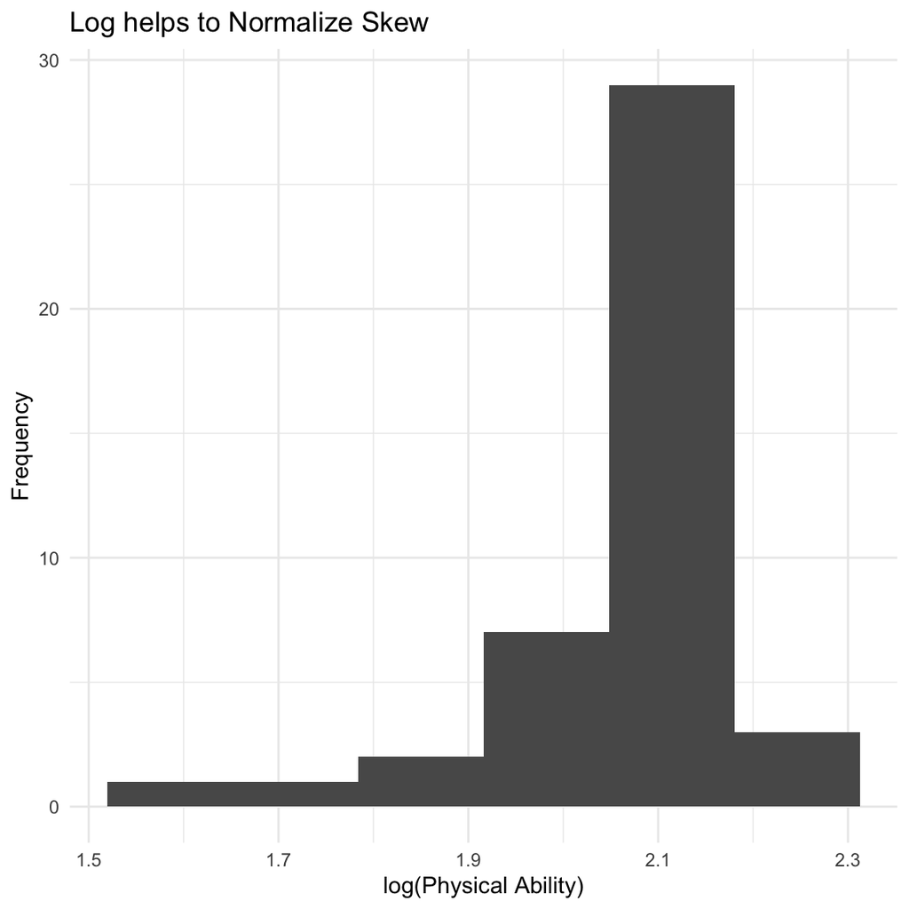

```r
ggplot(judges, aes(log(PHYS))) +
  geom_histogram(bins = 6) +
  theme_minimal() +
  labs(x = "log(Physical Ability)", y = "Frequency", title = "Log helps to Normalize Skew")
```

Below I create model object `mod.log3` where I predict the log of Physical ability from rated Demeanor and Diligence. Since we logged the DV, it is now a bit trickier to interpret the estimates.

```r
mod.log3 <- lm(log(PHYS) ~ DMNR + DILG, judges)
summary(mod.log3)
```

```
##
## Call:
## lm(formula = log(PHYS) ~ DMNR + DILG, data = judges)
##
## Residuals:
##      Min       1Q   Median       3Q      Max
## -0.35451 -0.01973 -0.00142  0.03655  0.14773
##
## Coefficients:
##             Estimate Std. Error t value Pr(>|t|)
## (Intercept)  1.20139    0.10898  11.024 1.08e-13 ***
## DMNR         0.04285    0.02010   2.132  0.03922 *
## DILG         0.07017    0.02552   2.750  0.00891 **
## ---
## Signif. codes:  0 '***' 0.001 '**' 0.01 '*' 0.05 '.' 0.1 ' ' 1
##
## Residual standard error: 0.08155 on 40 degrees of freedom
## Multiple R-squared:  0.6465, Adjusted R-squared:  0.6288
## F-statistic: 36.57 on 2 and 40 DF,  p-value: 9.311e-10
```

Therefore, I have exponentiated the estimates below. Your task is to interpret the `DMNR` and `DILG` rows using the provided template.

```r
mod.log3 %>%
  tidy() %>%
  mutate(exp =  exp(estimate))
```

```
## # A tibble: 3 x 6
##   term        estimate std.error statistic  p.value   exp
##   <chr>          <dbl>     <dbl>     <dbl>    <dbl> <dbl>
## 1 (Intercept)   1.20      0.109      11.0  1.08e-13  3.32
## 2 DMNR          0.0428    0.0201      2.13 3.92e- 2  1.04
## 3 DILG          0.0702    0.0255      2.75 8.91e- 3  1.07
```

For each additional unit that `DMNR` increases, the `PHYS` is expected to be [higher/lower], on average, by a factor of [insert here].

For each additional unit that `DILG` increases, the `PHYS` is expected to be [higher/lower], on average, by a factor of [insert here].